# Trabalho Computacional - Teoria da Decisão - UFMG

## Convergência

- O algoritmo completo utilizado para convergência considerou as combinações de espaços de busca de $\boldsymbol M_{\boldsymbol ( \boldsymbol 8, \boldsymbol 8 \boldsymbol ) }$ até $\boldsymbol M_{ \boldsymbol ( \boldsymbol 1 \boldsymbol 5 \boldsymbol 0 \boldsymbol , \boldsymbol 1 \boldsymbol 5 \boldsymbol 0 \boldsymbol )}$ contabilizando o mínimo de **64** o máximo de **22500** coordenadas para possíveis localizações dos pontos de acesso.
- O mapa de superfície tridimensional foi construído para ilustrar as regiões de inspeção do algoritmo. O gradiente das cores **azul(máximo)** e **vermelho(mínimo)** foi utilizado como a terceira dimensão do gráfico para ilustrar o número de pontos de acesso necessários para atingir um mínimo local ou global em cada combinação de espaços discretos.

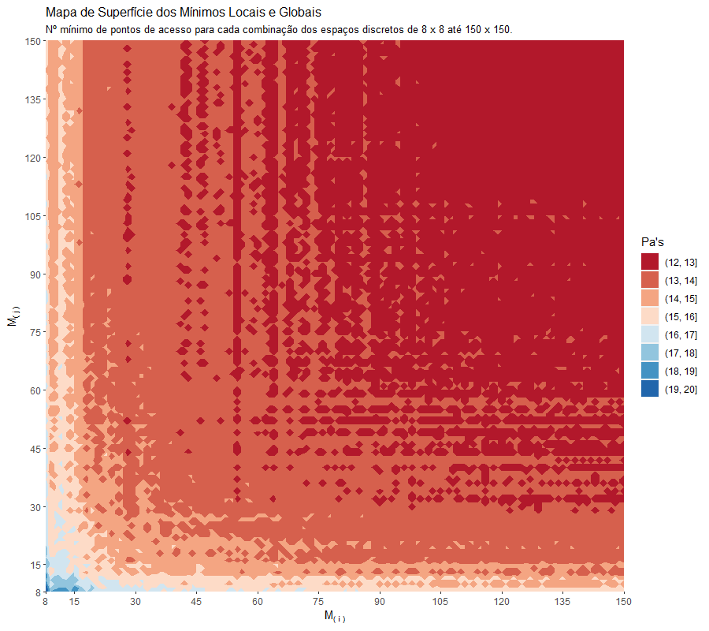

- O ponto na coordenada **i = 8** do eixo $\boldsymbol M_{ \boldsymbol ( \boldsymbol i \boldsymbol )}$ e **j = 8** do eixo $\boldsymbol M_{ \boldsymbol ( \boldsymbol j \boldsymbol )}$, corresponde a inspeção do espaço de busca $\boldsymbol M_{ \boldsymbol ( \boldsymbol 8 \boldsymbol , \boldsymbol 8)}$ que atinge a pior solução ótima de mínimo local gastando **20 Pa’s**.
- Entre $\boldsymbol M_{ \boldsymbol ( \boldsymbol 8 \boldsymbol , \boldsymbol 8 \boldsymbol )}$ e $\boldsymbol M_{ \boldsymbol ( \boldsymbol 3 \boldsymbol 0 \boldsymbol , \boldsymbol 3 \boldsymbol 0 \boldsymbol )}$ o algoritmo passa pelos mínimos locais de **20** até **13 Pa’s**, em $\boldsymbol M_{\boldsymbol ( \boldsymbol 2 \boldsymbol 7 \boldsymbol , \boldsymbol 4 \boldsymbol 3 \boldsymbol )}$ atinge pela primeira vez o mínimo global de **12 Pa’s** e em $\boldsymbol M_{ \boldsymbol ( \boldsymbol 9 \boldsymbol 0 \boldsymbol , \boldsymbol 7 \boldsymbol 5 \boldsymbol )}$ o algoritmo começa a estabilizar em **12 Pa’s** com a maioria dos espaços convergindo para **12 Pa’s**.
- O algoritmo estabiliza em **12 Pa´s** para espaços discretos mais granulares que $\boldsymbol M_{ \boldsymbol ( \boldsymbol 1 \boldsymbol 1 \boldsymbol 0 \boldsymbol , \boldsymbol 1 \boldsymbol 1 \boldsymbol 0 \boldsymbol )}$. Tal fato indicou convergência porque até $\boldsymbol M_{ \boldsymbol ( \boldsymbol 1 \boldsymbol 5 \boldsymbol 0 \boldsymbol , \boldsymbol 1 \boldsymbol 5 \boldsymbol 0 \boldsymbol )}$ o número de **Pa’s** permanece em **12**.

## Custo Computacional

- As performances de custo computacional do algoritmo nas combinações de espaços de busca foram comparadas utilizando a função **Sys.time** do **R**. O hardware utilizado foi um processador **Intel i7** com **16 GB RAM**.
- O mapa de superfície tridimensional foi construído para ilustrar os tempos computacionais necessários para atingir um mínimo local ou global em cada combinação de espaços discretos.

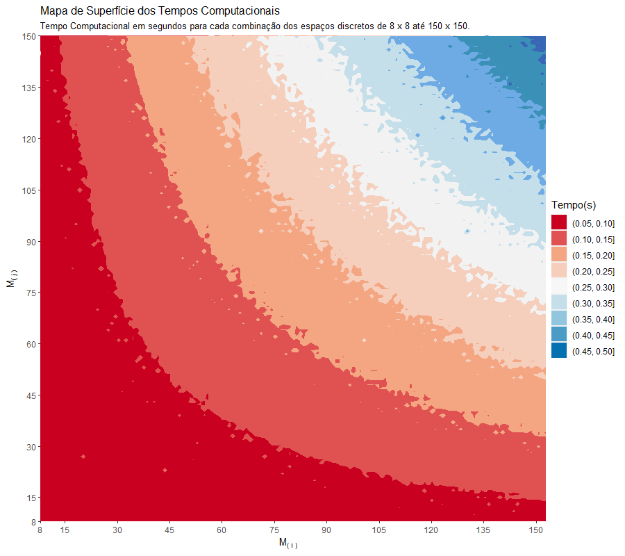

## Mínimo Global

- A solução ótima de mínimo global considerou o espaço de busca $\boldsymbol M_{ \boldsymbol ( \boldsymbol 1 \boldsymbol 1 \boldsymbol 0 \boldsymbol , \boldsymbol 1 \boldsymbol 1 \boldsymbol 0 \boldsymbol )}$ totalizando **12100** coordenadas de possíveis localizações para os pontos de acesso. Essa solução foi escolhida porque é um ponto de transição da convergência para estabilização do mínimo global.
- O algoritmo inspecionou o espaço de busca de **12100** possíveis localizações para os pontos de acesso e recuperou as localizações de **12** coordenadas que minimizam o número de pontos de acesso e satisfazem as condições do problema.

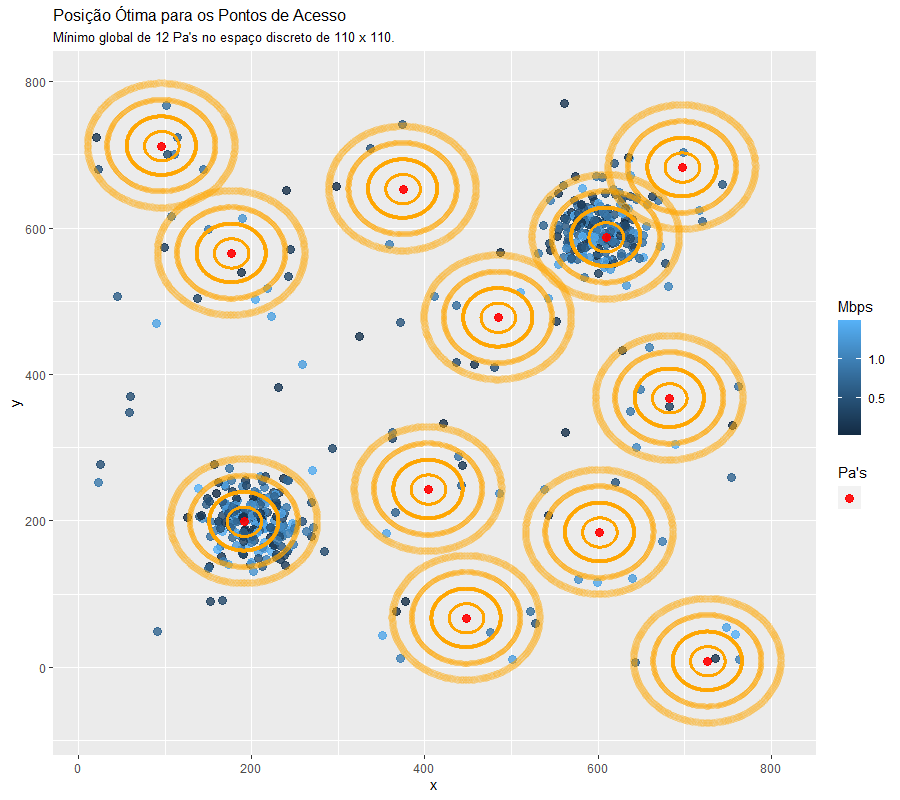

## Tabela de Resultados

- Tabela de localização dos **12 Pa’s** na área de **800 x 800** com os respectivos consumos totais em **Mbps**:

| Pa | x | y | Consumo (Mbps) |
| --- | --- | --- | --- |
| 1 | 192 | 199 | 147.2 |
| 2 | 609 | 587 | 148.1 |
| 3 | 177 | 565 | 6.9 |
| 4 | 683 | 368 | 6.7 |
| 5 | 485 | 477 | 5.7 |
| 6 | 404 | 243 | 5.8 |
| 7 | 697 | 683 | 5.4 |
| 8 | 602 | 184 | 6.6 |
| 9 | 96 | 712 | 4.2 |
| 10 | 448 | 67 | 3.7 |
| 11 | 727 | 8 | 4.6 |
| 12 | 375 | 653 | 2.1 |

- É possível observar que os dois clusters principais com um total de **147** e **148** Mbps de consumo estão muito próximos da saturação e talvez fosse adequado a colocação de mais **2 Pa’s** nessas regiões para garantir a integridade da entrega do sinal onde há maior concentração de **pontos de demanda**.
- Outra possível consideração seria a de que a diminuição da cobertura de cada **Pa** de **95%** ou **475 Pd’s** para **90%** ou **450 Pd’s** reduziria o custo total de **Pa’s** em **33%** ou seja de **12** para **8 Pa’s**.

## Tomada de Decisão

- Os resultados convenceram a unidade de decisão de que pequenas variações nas restrições do problema poderiam resultar em soluções consideravelmente distintas. Estes resultados explicavam que a flexibilização da quantidade mínima de **Pd’s** cobertos por todos os **Pa’s** e a quantidade máxima da demanda de banda também poderiam gerar resultados interessantes sem comprometer a qualidade do serviço de forma significativa.
- Na última reunião a **unidade de decisão** se mostrou flexível em alterar algumas restrições como número de **Pd’s** cobertos e capacidade máxima em **Mbps** de cada **Pa**. A unidade de decisão enviou um item da ata dessa reunião com os dizeres.
- *A empresa precisa garantir a **qualidade do serviço** e como os resultados mostraram que os **Pa’s** iriam operar em sua capacidade máxima, mas reduzir custo deve ser a prioridade na escolha da solução. Contudo é fato conhecido no registro histórico de operações da empresa que a diferença entre clientes registrados e presentes em conferências é geralmente maior que **5%** e, portanto, o relaxamento desse critério também deve ser considerado prioridade. A terceira e última prioridade seria a variação de ambos os parâmetros. Solicitar ao departamento de **BI** que gere diferentes cenários com base nessas diretrizes para orientar a unidade de decisão.*
- Como resposta o departamento de departamento **BI** implementou o método AHP *Analytic Hierarchy Process* para auxiliar a **unidade de decisão** na comparação. Para esta tarefa foram criados 3 robôs posicionadores que representam possíveis cenários a serem considerados pela **unidade de decisão**:
  - O Otimizador 1 Mbps reduz a capacidade máxima de largura de banda
  - O Otimizador 2 cobertura reduz o número total de **Pd’s** cobertos
  - O Otimizador 3 Mbps e Cobertura altera ambos os critérios.

### Características dos Otimizadores Candidatos:

- Para elaborar diferentes cenários foram considerados 3 otimizadores.

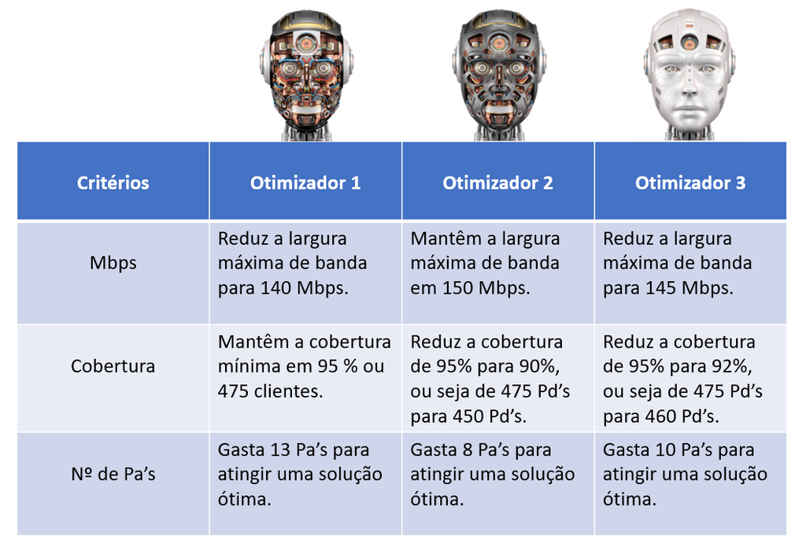

- As características desses otimizadores foram baseadas na performance do algoritmo para cada um desses otimizadores e as considerações da unidade de decisão.

### Diagrama AHP:

- O digrama AHP foi construído para ilustrar a comparação par a par entre os otimizadores e os critérios da unidade de decisão.

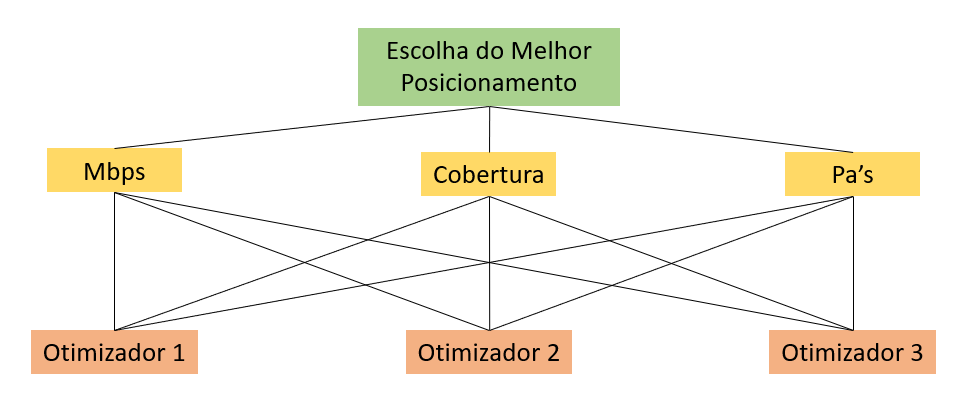

- As relações entre os otimizadores possuem estrutura hierárquica porque a ideia é que o AHP escolha não o melhor candidato, mas o que mais se adequa aos critérios da unidade de decisão.

### Critério Máximo Mbps:

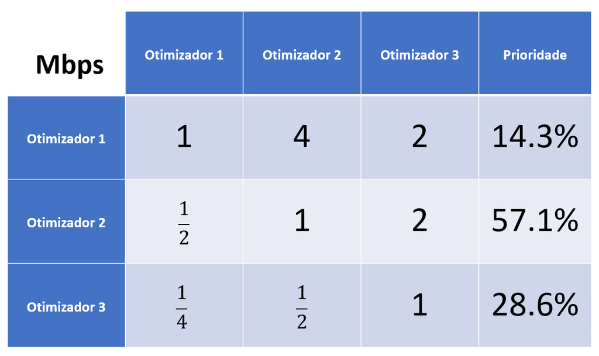

### Critério Cobertura:

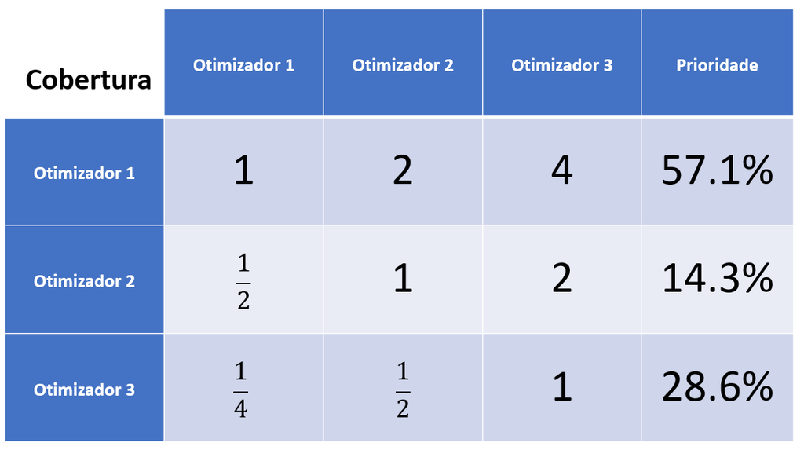

### Critério Número de Pa’s:

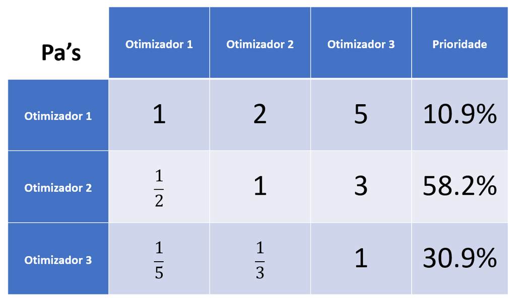

### Critério Unidade de Decisão:

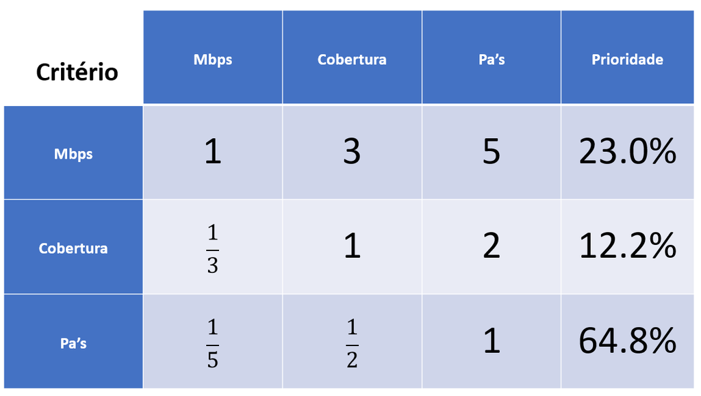

### Resultado do AHP:

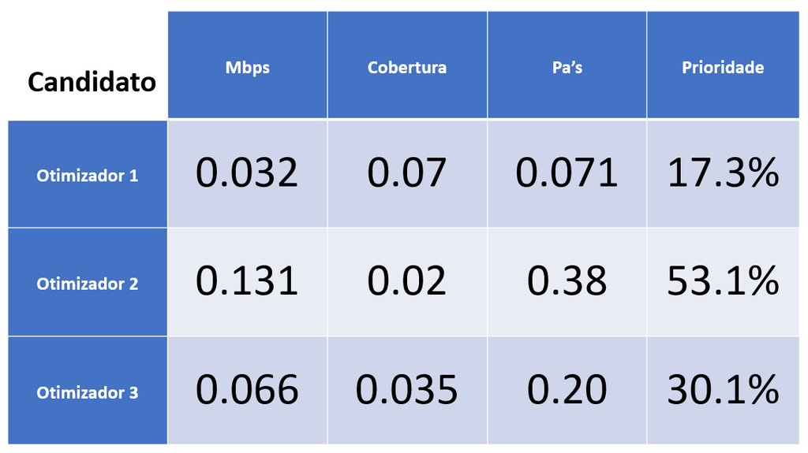

## Otimizador em Produção

- A unidade de decisão gostou da solução e optou pelo otimizador 2. Porém solicitou que o modelo do algoritmo otimizador fosse colocado em produção para operações futuras. A unidade de decisão também solicitou que fosse construída uma interface gráfica para utilização do modelo com botões para os parâmetros de Mbps, Cobertura e Granularidade do Espaço de Busca.
- Para atender a demanda da unidade de decisão o departamento de BI da empresa desenvolveu o aplicativo otimizador.
- Este programa iterativo é composto de uma barra lateral para carregar um arquivo **.csv** com 3 colunas. A primeira e a segunda são referentes às coordenadas **(x,y)** dos pontos de demanda e a terceira ao consumo de banda de cada ponto de demanda em Mbps. O painel é composto de um gráfico que mostra o posicionamento dos **Pa’s** e uma tabela que mostra a localização exata de cada **Pa**, bem como a largura de banda que será demandada.
- Esta ferramenta irá permitir que a unidade de decisão analise os cenários em tempo real otimizando o tempo humano gasto pela unidade de decisão para escolher o melhor cenário. Outra vantagem é que a unidade decisão poderá fazer ajustes finos no otimizador ao invés de escolher entre opções pré-configuradas anteriormente.

### Aplicativo

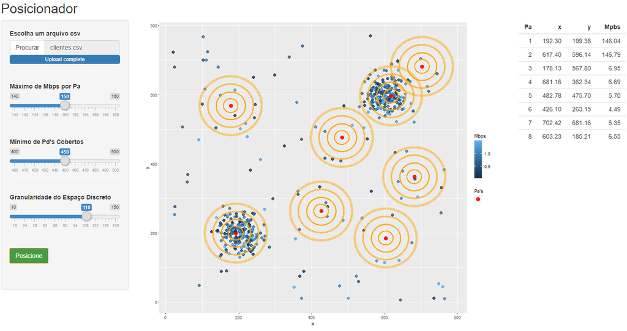

## Referências

- Para desenvolver este trabalho foram utilizados os slides e vídeos fornecidos pelo Professor Lucas Batista do departamento de *Engenharia de Sistemas* da *UFMG*.
- Devido a questões legais de proteção aos direitos autorais e regras da *UFMG*, os slides e vídeos não puderam ser compartilhados.
- [https://en.wikipedia.org/wiki/Analytic_hierarchy_process_leader_example](https://en.wikipedia.org/wiki/Analytic_hierarchy_process_%E2%80%93_leader_example)